# Paka Tagging Paper

#### Loading in all libraries.

###### Importing principle dependencies

```r
# install.packages('marmap')
library('marmap') # bathymetry()
# install.packages('lubridate')
library('lubridate') # floor_date(), ceil_date()
# install.packages('doParallel')
library('doParallel') # foreach()
# install.packages('beepr')
library('beepr') # beep
# install.packages('dplyr')
library('dplyr') # filter()
# install.packages('useful')
library('useful') # compare.list()
# install.packages('RAtmosphere')
library('RAtmosphere')
# install.packages('geosphere')
library('geosphere') # areaPolygon(), # distGeo() Note: wrapped in old lldist function
# install.packages('igraph')
library('igraph') # graph.adjacency()
# install.packages('notifyR')
library('notifyR') # send_push()
# install.packages('png')
library('png')
# install.packages('lunar')
library('lunar') # lunar.phase()
# install.packages('suncalc')
library('suncalc') # getSunlightTimes
# install.packages('data.table')
library('data.table') # uniqueN
# install.packages('lattice')
library('lattice')
# install.packages('ncdf4')
library('ncdf4') #nc_open()
# install.packages('xts')
library('xts')
registerDoParallel(cores = 7)
```

Loading in our data

```r
zk_hours_at_liberty_04 = c(0, 280.8, 0.1, 106.5, 37.3, 8.0, 348.8, 139.2, 277.4, 1475.3, 54.2, 1475.7, 1375.4)
zk_days_at_liberty_04 = zk_hours_at_liberty_04 / 24
fivenum(zk_days_at_liberty_04)
```

```
[1]  0.000000  1.554167  5.800000 14.533333 61.487500
```

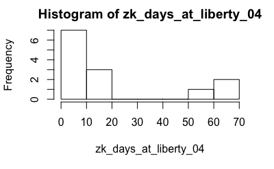

```r
hist(zk_days_at_liberty_04)
```

```r
zk_hours_at_liberty_07 = c(14, 43, 1.2, 25, 116, 46, 96, 14, 1.3, 9, 0.3)
zk_days_at_liberty_07 = zk_hours_at_liberty_07 / 24
fivenum(zk_days_at_liberty_07)
```

```
[1] 0.0125000 0.2145833 0.5833333 1.8541667 4.8333333
```

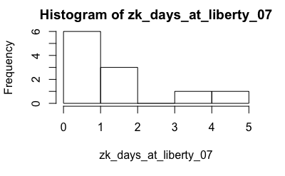

```r
hist(zk_days_at_liberty_07)
```

#### How many receiver stations were recovered?

How many receiver stations did we recover in the last analysis period of the project

```r
dim(receiver_data[receiver_data$deployment_date >= as.POSIXct('2017-04-01') & receiver_data$recovery_date >= as.POSIXct('2018-04-01') & !is.na(receiver_data$recovery_date) & receiver_data$recovered == '', ])[1]
```

```
[1] 39
```

#### Calculating Habitat Size

Adult bottomfish habitat is defined as waters with depths between 100 and 400 m. We want to know how much habitat area is available in BRFA E.

```r
area_sq_km
```

```
[1] 48.59374
```

### Shark Info

```r
shark_tags
```

```
 [1] "36816" "36815" "51595" "36814" "36818" "36808" "36809" "36813" "36812" "36811"
```

#### Getting Period of Analysis

We need to decide what our analysis period is. To make comparisons between fish, we need to limit our analysis to a specific period. We will use the period of maximum receivers. This period began sometime in June 2017.

```r
print(period_start)
```

```
[1] "2017-06-26 HST"
```

Similarly we know that we want to end the analysis period when the first receiver was pulled from the water (or in this case, when 338 broke it’s mooring.) This occurred sometime in spring 2018.

```r
print(period_end)
```

```
[1] "2018-04-15 HST"
```

#### Tag Status

Let’s first eliminate any detections that have been flagged as potentially false

```r
vue_data = vue_data[vue_data$detection_status == TRUE, ]
```

Now we run our data through our mortality algorthm to catagorize status and subset out just the opakapaka

```r
track_status_all = determine_track_status(vue_df = vue_data[vue_data$tag_id %in% tagging_data$vem_tag_id[tagging_data$species == 'Opakapaka'], ], bathymetry = get_bathymetry('mhi', 'low'))
```

[output not shown]

```r
beep()
```

Which of these “valid” tags were detected in our analysis period. Run our analysis on this and make six pannel plots for each so we can validate

```r
unique(vue_data$tag_id[vue_data$datetime >= period_start])
```

```
  [1] "61391" "36816" "5"     "61387" "61385" "61374" "61388" "927"   "926"   "61375"
 [11] "11"    "61389" "61382" "61380" "6"     "61381" "12"    "17"    "925"   "30721"
 [21] "61392" "61390" "30733" "61384" "61386" "61383" "61376" "61379" "35"    "36815"
 [31] "51595" "30722" "36810" "30"    "30724" "30736" "30729" "37"    "51583" "51586"
 [41] "30737" "30716" "30726" "40"    "30723" "51588" "30738" "51581" "30719" "30730"
 [51] "30732" "30735" "30717" "30741" "51584" "30718" "36814" "30720" "36818" "30715"
 [61] "30714" "30731" "29"    "1"     "51582" "30739" "33"    "18"    "36808" "36809"
 [71] "7"     "51600" "20"    "32"    "30734" "924"   "39"    "14"    "30742" "51587"
 [81] "51585" "10"    "30743" "30744" "30746" "51599" "30709" "51596" "30679" "30680"
 [91] "30681" "30682" "30683" "30748" "30684" "30685" "30686" "30687" "30688" "30689"
[101] "30690" "30691" "30693" "30695" "30747" "30694" "30700" "30692" "30702" "30703"
[111] "30698" "30701" "30745" "30706" "30708" "30705" "30712" "30713" "51597" "30707"
[121] "51589" "30697" "30704" "51598" "30699" "30725" "13"    "3"     "2111"  "2116"
[131] "2117"  "2122"  "2126"  "2118"  "2115"  "2138"  "2125"  "2124"  "2139"  "2140"
[141] "2119"  "2129"  "2145"  "2135"  "2142"  "2146"  "2137"  "2150"  "2131"  "2149"
[151] "2112"  "2141"  "2136"  "2144"  "2128"  "2133"  "2127"  "2120"  "36813" "2155"
[161] "2152"  "2154"  "2157"  "2159"  "2156"  "36812" "2147"  "2130"  "28183" "28184"
[171] "28182" "28176" "28185" "28177" "28181" "36811" "28173" "30750" "28169" "28180"
[181] "30751" "28179" "30753" "28175" "28166" "28171" "30752" "28174" "30749" "2121"
[191] "28170" "28178" "2114"  "2132"  "28172" "2113"  "2123"  "2158"  "16"
```

How many tags did we put out?

```r
tagged_ids
```

```
  [1]    20    13    14    18    24    19    17    16     9    10    11    12     8     7
 [15]     6     5     4     1     3     2    32    31    30 51581    29    36    35    33
 [29]    34    37    38    39    40 51582 51583 51584 51586 51585 51587 51588   927   923
 [43]   924   925   926 30714 30715 36810 30716 30717 30718 30719 30720 30721 30722 30723
 [57] 30724 30725 30726 30727 30728 30729 30730 30731 30732 30733 30734 30735 30736 30737
 [71] 30738 30739 30740 30741 30742 30743 30744 51599 30746 30747 51596 30709 30679 30680
 [85] 30681 30682 30683 30684 30685 30686 30687 30689 30690 30694 30695 30696 30697 30700
 [99] 30701 30702 30703 30704 30705 30706 30707 30708 30710 51597 51598  2111  2112  2114
[113]  2115  2116  2117  2118  2119  2120  2121  2122  2124  2125  2126  2127  2128  2129
[127]  2130  2131  2132  2133  2134  2135  2136  2137  2138  2139  2140  2141  2142  2143
[141]  2144  2145  2146  2147  2149  2150  2151  2152  2153  2154  2155  2156  2157  2158
[155]  2159  2160 28181 28182 28183 28184 28185 28176 28177 28178 28179 28180 28171 28173
[169] 28174 28175 28170 28169 28168 28166 30749 30750 30751 30752 30753
```

Lets see whats alive…

```r
valid_tags
```

```
 [1] "12"    "2127"  "2133"  "2136"  "2139"  "2140"  "2157"  "28179" "30684" "30685" "30705"
[12] "30721" "30729" "51582" "51586" "51588" "51596" "6"
```

… and reassign things we think the algorthm got wrong.

```r
valid_tags
```

```
 [1] "2133"  "2136"  "28179" "30684" "30705" "30721" "36808" "36811" "36812" "36814" "36815"
[12] "36816" "36818" "51582" "51586" "51588" "51595" "51596" "51600" "61385" "61389"
```

Now we’ll construct a table to summarize all of this

| Status | Assigned Algorthmically |
| --- | --- |
| Alive | 18 |
| Dead | 73 |
| Excluded From Analysis | 41 |
| Unknown | 25 |

Calculating survivorship

```r
## Without Excluded Tags
length(valid_tags) / length(c(valid_tags, questionable_tags, dead_tags))

length(c(questionable_tags, valid_tags)) / length(c(valid_tags, questionable_tags, dead_tags))

## With Excluded Tags
length(valid_tags) / length(c(valid_tags, questionable_tags, dead_tags, excluded_tags))

length(c(questionable_tags, valid_tags)) / length(c(valid_tags, questionable_tags, dead_tags, excluded_tags))
```

Getting Tagging info

```r
  ## What was the minimum tagging date of our valid fish
  min(tagging_data$datetime[tagging_data$vem_tag_id %in% valid_tags])

  ## Earliest reported tagging date
    start_tagging_date = as.POSIXct('2017-01-09')

  ## How many opakapaka were tagged after that date?
    length(tagging_data$unique_id[tagging_data$datetime >= start_tagging_date & tagging_data$species == 'Opakapaka'])

  ## How many tags were detected on the array?
  length(unique(vue_data$tag_id[vue_data$datetime >= '2017-06-26' & vue_data$tag_id %in% unique(tagging_data$vem_tag_id[tagging_data$species == 'Opakapaka'])]))

  ## How many tags detected were 'valid'
length(valid_tags)

  ## How many tags detected were 'questionable'
   length(questionable_tags)

  ## How many tags are straight up dead?
   length(dead_tags)

  ## How many tags were excluded?
   length(excluded_tags)

  ## How many tags never appeared on the array?
   length(never_detected)

  vue_data = vue_data[vue_data$datetime >= start_date & vue_data$datetime < end_date, ]
```

Running our analyses

```r
valid_data = run(run_description = "Spring 2018 - Valid Track Data without Plots",
                      vue_df = vue_data,
                      receiver_df = receiver_data,
                      tagging_df = tagging_data,
                      start_date = as.POSIXct('2017-06-26'),
                      end_date = as.POSIXct('2018-04-15'),
                      region = "Makapuu",
                      plot = FALSE,
                      tag_ids = valid_tags
)
```

```
[1] "Let's Do This."
```

[output not shown]

```
[1] "All fish were tracked a collective distance of 32752.92 km"
```

[output not shown]

[output not shown]

#### Calculating tagging date range for fish

```r
range(phase_10_valid$tagging_date$tagging_date)

## Subset tagging data
subset_tagging_data = tagging_data[tagging_data$datetime >= floor_date(min(range(phase_10_valid$tagging_date$tagging_date)), unit = 'day') & tagging_data$species == "Opakapaka" & !is.na(tagging_data$vem_tag_id), ]

## How many individuals tagged?
length(subset_tagging_data$unique_id) -1 # Note on tag 925 indicates individual was dead.

## How many individuals tagged with pressure tags?
length(which(tolower(subset_tagging_data$vem_tag_type) == 'v13p')) - 13

## How were these fish tagged?
aggergate(subset_tagging_data$vem_tag_id, by = list(subset_tagging_data$release_method), FUN = length)

## How many of these fish ended up super dead?
track_status = determine_track_status(vue_df = vue_data[vue_data$tag_id %in% subset_tagging_data$vem_tag_id, ])

## How many fish showed up on the array?
length(which(subset_tagging_data$vem_tag_id %in% vue_data$tag_id))

## How many Pressure tags showed up on the array?
length(which(subset_tagging_data$vem_tag_id[tolower(subset_tagging_data$vem_tag_type) == 'v13p'] %in% vue_data$tag_id))

## What was transmission interval of tags?
unique(tag_specs$min_interval_sec[tag_specs$tag_id %in% subset_tagging_data$vem_tag_id])

unique(tag_specs$max_interval_sec[tag_specs$tag_id %in% subset_tagging_data$vem_tag_id])
```

How many fish were tagged total in this period?

```r
tagging_data.period = tagging_data[tagging_data$datetime >= as.POSIXct('2017-01-9') & tagging_data$species == "Opakapaka", ]
dim(tagging_data.period)[1]
```

How many tags were detected on the array in this period?

```r
tagging_data.detected = tagging_data.period[tagging_data.period$vem_tag_id %in% vue_data$tag_id[vue_data$datetime >= period_start], ]

dim(tagging_data.detected)[1]
```

How many were pressure tags?

```r
length(which(tagging_data.detected$vem_tag_type == 'V13P'))
```

How many fish of each status?

```r
length(which(track_status.detected$status == "Alive"))

length(which(track_status.detected$status == "Questionable"))

length(which(track_status.detected$status == "Dead"))

length(which(track_status.detected$status == "Excluded From Analysis"))
```

How many fish never detected?

```r
length(unique(tagging_data.period$vem_tag_id)) - length(unique(tagging_data.detected$vem_tag_id))
```

What was survivorship rate for tags minus tags with insufficent data

```r
length(valid) / length(track_status$tag_id[track_status$tag_id %in% tagging_data.detected$vem_tag_id & track_status$status != "Excluded From Analysis"])
```

### Getting results for each run scenario

```r
## Mean and sd time at liberty
mean(valid_data$time_at_liberty$days_at_liberty)
sd(valid_data$time_at_liberty$days_at_liberty)

## Mean and sd time at liberty
mean(valid_and_quest_data$time_at_liberty$days_at_liberty)
sd(valid_and_quest_data$time_at_liberty$days_at_liberty)

valid_time_at_lib = calculate_time_at_liberty(vue_df = vue_data[vue_data$datetime >= period_start & vue_data$datetime < period_end & vue_data$tag_id %in% valid_tags, ])

quest_time_at_lib = calculate_time_at_liberty(vue_df = vue_data[vue_data$datetime >= period_start & vue_data$datetime < period_end & vue_data$tag_id %in% c(valid_tags, questionable_tags), ])
```

#### Testing Receiver Fence Robustness

We are going to test the robustness of our receiver gates by looking at the detection rate of a sync tag (located within one of our VR2ARs) at a receiver station located a fixed distance away.

The workspace we have preloaded contains our detection database (vue_df) and our receiver locations (receiver_df). We have also loaded a handfull of helpful functions. Let’s first look at a map of our study area:

```r
plot_receiver_map(receiver_data, receiver_numbers = TRUE, save_plot = FALSE)
```

[output not shown]

```r
tag_id = 61375 # From receiver "Oahu - Makapuu BRFA 336"
station_id = "Oahu - Makapuu BRFA 14"
receiver_id = receiver_data$vr2w_serial[which(receiver_data$station_name == station_id & receiver_data$deployment_date > as.POSIXct('2017-06-01') & !is.na(receiver_data$recovery_date))]
vue_df = raw_vue_data
vue_df = vue_df[vue_df$datetime > fy2018 & vue_df$tag_id == tag_id & vue_df$receiver == receiver_id, ]
vue_df = clean_vue_data(vue_df, receiver_data)
dist = distance_between_receivers(receiver_df = receiver_data, start_date = fy2018)
dist['Oahu - Makapuu BRFA 14', "Oahu - Makapuu BRFA 336"] * 1000 # m
  print(paste('Station 14 and Station 336 are', round(dist['Oahu - Makapuu BRFA 14', "Oahu - Makapuu BRFA 336"] * 1000, digits = 0), 'm from one another', sep = " "))
```

It would be helpful to understand how far apart fence receivers are in space. We should look at the maximum distance between any two nodes in each of the four fences to understand the space relationships between subsequent nodes.

Note that because detection envelopes are probability distributions, detection probability is additive when detection envelopes overlap. Therefore the distance between two subsequent receivers is usefull, but half that distance (the midpoint between two receivers), is what we will actually look at to understand detection rates

```r
 ## Which receivers were parts of fence?
  outside_north = paste('Oahu - Makapuu BRFA', c(5, 4, 3, 2))
  outside_south = paste('Oahu - Makapuu BRFA', c(311, 312, 313, 314, 315, 316, 317, 318, 319, 320))
  inside_north = paste('Oahu - Makapuu BRFA', c(331, 332, 333))
  inside_south = paste('Oahu - Makapuu BRFA', c(334, 335, 336, 337, 338, 339, 340, 341))

  ## How far apart were receivers spaced?
  outside_north_receiver_dist_mat = distance_between_receivers(receiver_data[receiver_data$station_name %in% outside_north, ], start_date = fy2018, end_date = fy2018 + (24*60*60), include_lost = TRUE)
    range(apply(outside_north_receiver_dist_mat$matrix, 1, min, na.rm = TRUE))

  outside_south_receiver_dist_mat = distance_between_receivers(receiver_data[receiver_data$station_name %in% outside_south, ], start_date = fy2018, end_date = fy2018 + (24*60*60), include_lost = TRUE)
    range(apply(outside_south_receiver_dist_mat$matrix, 1, min, na.rm = TRUE))

  inside_north_receiver_dist_mat = distance_between_receivers(receiver_data[receiver_data$station_name %in% inside_north, ], start_date = fy2018, end_date = fy2018 + (24*60*60), include_lost = TRUE)
    range(apply(inside_north_receiver_dist_mat$matrix, 1, min, na.rm = TRUE))

  inside_south_receiver_dist_mat = distance_between_receivers(receiver_data[receiver_data$station_name %in% inside_south, ], start_date = fy2018, end_date = fy2018 + (24*60*60), include_lost = TRUE)
    range(apply(inside_south_receiver_dist_mat$matrix, 1, min, na.rm = TRUE))

  ## Which fence nodes were lost? When?
  View(receiver_data[receiver_data$recovered != "" & receiver_data$recovery_date >= fy2018 & receiver_data$deployment_date <= fy2018, ])
  View(receiver_data[receiver_data$station_name == 'Oahu - Makapuu BRFA 338', ])

  ## What does this mean for detection?
  inside_south_recovered_receiver_dist_mat = distance_between_receivers(receiver_data[receiver_data$station_name %in% inside_south & receiver_data$recovered == "", ], start_date = fy2018, end_date = fy2018 + (24*60*60), include_lost = TRUE)
  max_dist_between_is_fence_receivers = max(apply(inside_south_recovered_receiver_dist_mat$matrix, 1, min, na.rm = TRUE))
    max_dist_between_is_fence_receivers / 2
```

From our range testing results, we know that at 827 m, we should have an aproximate detection rate of 6.06 %. Let’s look at how many periods we had such a detection rate. We need to define how long each period is, the number of transmissions sent during each period and the number of those transmissions that were detected.

```r
## Binning hours into periods
hours_per_bin = 2
hourbins = seq.POSIXt(from = as.POSIXct('2017-08-30'), to = max(vue_df$datetime), by = 'hours')
  hourbins = hourbins[seq(from = 1, to = length(hourbins), by = hours_per_bin)]

## Calculating sent transmissions per period
  transmissions_per_hour = 6 * hours_per_bin

## Counting the number of detections from sync tag detected by station hourly
hourly_self_detections = c()
for(i in 1:length(hourbins)){
  hourly_self_detections = c(hourly_self_detections, length(vue_df$datetime[vue_df$datetime >= hourbins[i] & vue_df$datetime < hourbins[i+1]]))
}

## Plotting results
plot(hourly_self_detections ~ hourbins, pch = 19, cex = .5)

# What percentage of hourly detections were greater than the threshold?
length(which(hourly_self_detections >= transmissions_per_hour * 0.0606)) / length(hourbins)
  # 85.5%

# How many total hour bins are we talking about?
length(hourly_det)
```

I feel reasonably confident that this means the detection rate is adaquate at half that distance.

#### Fish Capture and Tagging

```r
## Minimum fork lengths
analysis_summary = fy2018_valid_and_uncertain
## Table of stuff
individual_fish_table = data.frame(
                            'Species' = "P. filamentosus",
                            'Tag ID' = analysis_summary$summary_df$tag_id,
                            'Track Status' = 'Questionable',
                            'Fork Length (cm)' = analysis_summary$summary_df$fork_length_cm,
                            'Tagging Date' = analysis_summary$summary_df$tagging_date,
                            'Days at Liberty' = analysis_summary$summary_df$days_at_liberty,
                            'Transmissions Detected' = analysis_summary$summary_df$n_detections,
                            'Unique Days Detected' = analysis_summary$summary_df$unique_days,
                            'Linear Home Range (km)' = analysis_summary$summary_df$z_constrained_path_distance,
                            'Movements Detected' = analysis_summary$summary_df$movements_detected,
                            'Movements Across BRFA Boundaries' = analysis_summary$summary_df$total_brfa_crossings,
                            stringsAsFactors = FALSE)
individual_fish_table$`Track.Status`[individual_fish_table$Tag.ID %in% valid_tracks] = 'Valid'
write.csv(individual_fish_table, 'Fish Table.csv')
```

We’ll wrap up by saving our analysis to a workspace image so we can go in and pick at it later if we need to

```r
save.image('../Manuscript/Manuscript Analysis Image')

valid_tags = c(2133, 2136, 28179, 30684, 30705, 30721, 51582, 51586, 51588, 51596)
questionable_tags = c(valid_tags, 2122, 2127, 2139, 2140, 2157, 28171, 28178, 28181, 28185, 30683, 30703, 30707, 30714, 30715, 30717, 30722, 30729, 30734, 30739, 30742, 30743, 30747, 30749,30751, 36810, 51581, 51584, 51585, 51587, 51598)
```